# FrameWorks and Method 1 Cheat Sheet

#### Prediction Algorithms

##### Decision Tree

**Where/when to use trees**

using large number of independent variables and

when there are likely to be non-linear relationships and interactions amongst variables.

And when interpretability of results is important

**Issues** perform poorly in predicting relative to the best supervised learning approaches tend to overfit the data

In decision tree the predictor space is divided into segments or it will be stratified and the predictions is made based on the summary of from that particular region.

**Process Of Spliting the data**

- The process begins with the entire data, R, and searches every distinct value of every predictor to find the predictor and split value that partitions the data into two groups (R1 and R2) such that the overall sum of squared errors is minimized.
- Next, the process is repeated, looking for the best predictor and best split value (or cut point) in order to split the data further so as to minimize the SSE within each of the resulting regions.
- However, this time, instead of splitting the entire predictor space, one of the previously identified regions is split. This creates three regions, R1, R2 and R3.Because of the recursive splitting nature of trees, this method is also known as recursive partitioning (and inspiration for the name of the R library, `rpart`).
- This recursive partitioning process continues until a stopping criterion is reached such as number of observations in a region falls below 5.

**Short Comes**

- It is computationally infeasible to consider every possible partition of the feature space into J boxes.
- This is the reason for the top-down, greedy approach of recursive binary splitting.
- The approach is top-down because it begins at the top of the tree and then successively splits the predictor space; each split is indicated via two new branches further down on the tree.
- It is greedy because at each step of the tree-building process, the best split is made at that particular step, rather than looking ahead and picking a split that will lead to a better tree in some future step.

**Predictor Importance**

- Relative importance of predictors in trees can be determined by examining the reduction in SSE attributed to each split.
- Intuitively, predictors that appear higher in the tree, or that appear multiple times in the tree will be more important than predictors that appear lower in the tree or not at all

**Summary** 1) Use recursive binary splitting to grow a large tree on the training data, stopping only when each terminal node has fewer than some minimum number of observations. 2) Apply cost complexity pruning to the large tree in order to obtain a sequence of best subtrees, as a function of cp. 3) Use k-fold cross-validation to choose α. For each k = 1, . . . , K: a) Repeat Steps 1 and 2 on the 𝐾−1/𝐾 th fraction of the training data, excluding the kth fold. b) Evaluate the mean squared prediction error on the data in the left-out kth fold, as a function of cp.

```
c) Average the results, and pick cp to minimize the average error.
```

4. Return the subtree from Step 2 that corresponds to the chosen value of cp .

A set of *segment rules* is used to segment the predictor space.

Decision Tree can be used for both predicting continuous outcome and categorical outcome.

It partitions the data into smaller group that has greater proportion of one of the categories of the outcome.

CART (classification and regression Tree methodology) is oldest and widely being used.

**Predictors include categorical and continuous variables: Trees can handle both categorical and continuous predictors Categorical variables can be handled automatically, without dummy coding.**

**Trees handles the predictors even if they are skewed. No transformation of predictors are required nor they need to be standardized. No need to create interaction term to explore join effect of 2 or more predictors** Joint effect here refers to how other variables include the outcome. Like for instance if a customer is purchasing the product then combination of age and income are the factors that influence the outcome variable. Decision tree will automatically handles these.

**Missing values are automatically handled by decision tree by using surrogate splits.**

Surrogate splits means if we have income which are having some missing values, decision tree will use surrogate split are created using other variables which are correlated with income like experience, job title etc.. this is only used as backup if primary split cannot be made on income due to missing data.

**Weakness of Trees** Less-than optimal predictive performance. – Tree models partition the predictor space into rectangular regions. If the relationship between predictors and outcome is not adequately described by these rectangles, performance will be poor. – Number of possible predicted outcomes is finite and is determined by the number of leaves. This limitation is unlikely to capture all of the nuances of the data.

Model instability – Slight changes in the data can drastically change the structure of the tree, hence the interpretation. Thus, these models have high variance. Easy to overfit train data

###### Regression Tree Continuous

###### Calssification Tree Categorical

**Loading Data**

```r
# Loading the Data
library(ISLR2)
data(Credit)
library(dplyr)
Credit2 =
  Credit %>%
  mutate(Balance_hilo = as.integer(Balance > median(Balance,na.rm = T)))%>%
  mutate(Balance_hilo = factor(Balance_hilo, labels = c('low','high'),ordered = T))%>%
  select(-Balance)
```

**Splitting Data**

```r
library(caret)
set.seed(1031)
split = createDataPartition(y = Credit2$Balance_hilo, p = 0.75, list = F)
train = Credit2[split,]
test = Credit2[-split,]
```

**Estimate**

For instance, for a 35 year old, one can navigate through the tree to arrive at a predicted probability of 0.43 for a “high” balance.

```r
library(rpart)
```

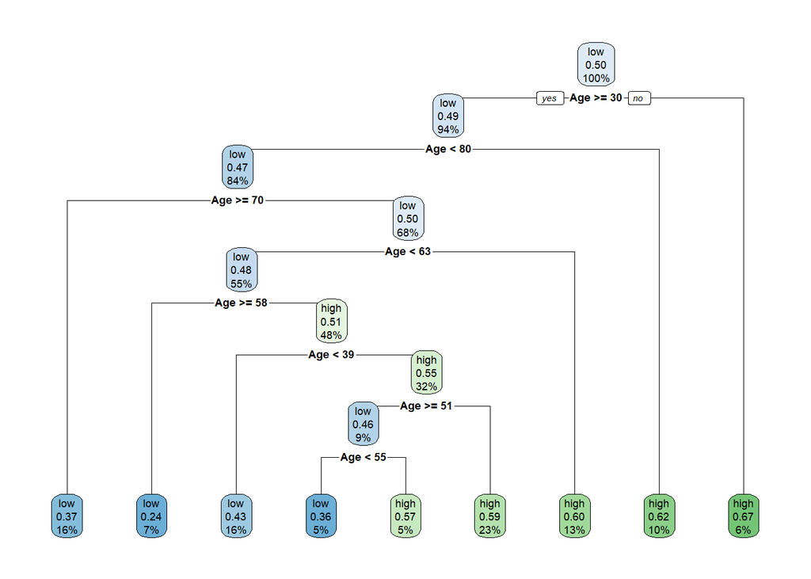

```r
library(rpart.plot)
tree1 = rpart(Balance_hilo~Age,data = train, method = 'class')
rpart.plot(tree1)
```

**Predict**

```r
predict(tree1, newdata = data.frame(Age = 35), type='class')
```

```
##   1
## low
## Levels: low high
```

```r
predict(tree1, newdata = data.frame(Age = 35), type='prob')[,'high'] > 0.5
```

```
## [1] FALSE
```

#### Data Tidying

##### Basic Parsings

```r
library(readr)
parse_number('increase in sales of €123.456,78',locale = locale(grouping_mark = '.'))
```

```
## [1] 123456.8
```

Parse character: However, UTF-8 encoding may not be human readable. Would you like ice cream from 6e2d7a?

```r
parse_character('\x48\xc3\xa4\x61\x67\x65\x6e\x2d\x44\x61\x7a\x73')
```

```
## [1] "Häagen-Dazs"
```

```r
parse_character("\U0001F4A9")
```

```
## [1] "💩"
```

**Dates**

Year %Y (4 digits) %y (2 digits); 00-69 -> 2000-2069, 70-99 -> 1970-1999

Month %m (2 digits) %b (abbreviated name, like “Jan”) %B (full name, “January”)

Day %d (2 digits). %e (optional leading space)

Time %H 0-23 hour %I 0-12, must be used with %p %p AM/PM indicator %M minutes %S integer seconds %OS real seconds %Z Time zone (as name, e.g. America/Chicago) %z (as offset from UTC, e.g. +0800)

Non-digits %. skips one non-digit character %* skips any number of non-digits

```r
as.Date('4/7/1776',format='%d/%m/%Y')
```

```
## [1] "1776-07-04"
```

```r
# lubridate provides a number of simple functions to convert date and time to the ISO standard.
library(lubridate)
mdy('7/4/1776')
```

```
## [1] "1776-07-04"
```

```r
dmy('4/7/1776')
```

```
## [1] "1776-07-04"
```

```r
mdy_hms('July 4, 1776 3:25:13 pm',tz = 'US/Eastern')
```

```
## [1] "1776-07-04 15:25:13 LMT"
```

**Extracting months, days, years once formated**

```r
month(mdy('7/4/1776'),label = T)
```

```
## [1] Jul
## 12 Levels: Jan < Feb < Mar < Apr < May < Jun < Jul < Aug < Sep < ... < Dec
```

```r
wday(mdy('7/4/1776'),label = T)
```

```
## [1] Thu
## Levels: Sun < Mon < Tue < Wed < Thu < Fri < Sat
```

**More Example**

```r
location = c('USA, north america','China,asia','India, asia', 'Russia, asia','France, europe','UK, europe')
national_day = c('July 4, 1776','October 1, 1949','August 15, 1947','June 12, 1990','July 14, 1789','none')
national_day_alt = c('4/7/1776','1/10/1949','15/8/1947','12/6/1990','14/7/1789','none')
per_capita_dollars = c('$65,280.70','$10,261.70','$2,104.10','$11,585.00','$40,493.90','$42,300.30')
per_capita_euros = c('55.488,59 Euro','8.722,44 Euro','1.788,48 Euro','9.847,25 Euro','34.419,82 Euro','35.955,26 Euro')
messy_data = data.frame(location, national_day, national_day_alt, per_capita_dollars,per_capita_euros)
# The dollar sign provides context to the numbers, however its presence gets in the way of conducting numerical analysis.
messy_data %>%
  mutate(per_capita_dollars = parse_number(per_capita_dollars))
```

```
##             location    national_day national_day_alt per_capita_dollars
## 1 USA, north america    July 4, 1776         4/7/1776            65280.7
## 2         China,asia October 1, 1949        1/10/1949            10261.7
## 3        India, asia August 15, 1947        15/8/1947             2104.1
## 4       Russia, asia   June 12, 1990        12/6/1990            11585.0
## 5     France, europe   July 14, 1789        14/7/1789            40493.9
## 6         UK, europe            none             none            42300.3
##   per_capita_euros
## 1   55.488,59 Euro
## 2    8.722,44 Euro
## 3    1.788,48 Euro
## 4    9.847,25 Euro
## 5   34.419,82 Euro
## 6   35.955,26 Euro
```

```r
# Like the per_capita_dollars, this variable contains the currency label. Furthermore, the numbers are formatted using a grouping convention common in Europe.

messy_data %>%
  mutate(per_capita_dollars = parse_number(per_capita_dollars))%>%
  mutate(per_capita_euros = parse_number(per_capita_euros, locale = locale(grouping_mark = '.')))
```

```
##             location    national_day national_day_alt per_capita_dollars
## 1 USA, north america    July 4, 1776         4/7/1776            65280.7
## 2         China,asia October 1, 1949        1/10/1949            10261.7
## 3        India, asia August 15, 1947        15/8/1947             2104.1
## 4       Russia, asia   June 12, 1990        12/6/1990            11585.0
## 5     France, europe   July 14, 1789        14/7/1789            40493.9
## 6         UK, europe            none             none            42300.3
##   per_capita_euros
## 1         55488.59
## 2          8722.44
## 3          1788.48
## 4          9847.25
## 5         34419.82
## 6         35955.26
```

```r
# Date format used is Month, Date, Year.
messy_data %>%
  mutate(per_capita_dollars = parse_number(per_capita_dollars))%>%
  mutate(per_capita_euros = parse_number(per_capita_euros, locale = locale(grouping_mark = '.')))%>%
  mutate(national_day = mdy(national_day))
```

```
##             location national_day national_day_alt per_capita_dollars
## 1 USA, north america   1776-07-04         4/7/1776            65280.7
## 2         China,asia   1949-10-01        1/10/1949            10261.7
## 3        India, asia   1947-08-15        15/8/1947             2104.1
## 4       Russia, asia   1990-06-12        12/6/1990            11585.0
## 5     France, europe   1789-07-14        14/7/1789            40493.9
## 6         UK, europe         <NA>             none            42300.3
##   per_capita_euros
## 1         55488.59
## 2          8722.44
## 3          1788.48
## 4          9847.25
## 5         34419.82
## 6         35955.26
```

**Separate**

```r
#An alternative to using regular expressions for extracting country and continent is to split continent based on the comma delimiter. The library tidyr has a function, separate that does just that. We will still use str_to_title to change case for continent. separate adds on some whitespace which is removed using str_trim.

messy_data %>%
  mutate(per_capita_dollars = parse_number(per_capita_dollars))%>%
  mutate(per_capita_euros = parse_number(per_capita_euros, locale = locale(grouping_mark = '.')))%>%
  mutate(national_day = mdy(national_day))%>%
  mutate(national_day_alt = dmy(national_day_alt))%>%
  separate(col = location,into = c('country','continent'), sep = ',')%>%
  mutate(continent = str_trim(str_to_title(continent)))%>%
  select(country,continent,everything())
```

```
##   country     continent national_day national_day_alt per_capita_dollars
## 1     USA North America   1776-07-04       1776-07-04            65280.7
## 2   China          Asia   1949-10-01       1949-10-01            10261.7
## 3   India          Asia   1947-08-15       1947-08-15             2104.1
## 4  Russia          Asia   1990-06-12       1990-06-12            11585.0
## 5  France        Europe   1789-07-14       1789-07-14            40493.9
## 6      UK        Europe         <NA>             <NA>            42300.3
##   per_capita_euros
## 1         55488.59
## 2          8722.44
## 3          1788.48
## 4          9847.25
## 5         34419.82
## 6         35955.26
```

**Using refactor (fct_recode), Rename, everything()

```r
head(messy_data)
```

```
##             location    national_day national_day_alt per_capita_dollars
## 1 USA, north america    July 4, 1776         4/7/1776         $65,280.70
## 2         China,asia October 1, 1949        1/10/1949         $10,261.70
## 3        India, asia August 15, 1947        15/8/1947          $2,104.10
## 4       Russia, asia   June 12, 1990        12/6/1990         $11,585.00
## 5     France, europe   July 14, 1789        14/7/1789         $40,493.90
## 6         UK, europe            none             none         $42,300.30
##   per_capita_euros
## 1   55.488,59 Euro
## 2    8.722,44 Euro
## 3    1.788,48 Euro
## 4    9.847,25 Euro
## 5   34.419,82 Euro
## 6   35.955,26 Euro
```

```r
data_1 = messy_data %>%
  mutate(per_capita_dollars = parse_number(per_capita_dollars)) %>%
  mutate(per_capita_euros = parse_number(per_capita_euros, locale = locale(grouping_mark = '.'))) %>%
  mutate(national_day_alt = dmy(national_day_alt)) %>%
  mutate(national_day = mdy(national_day)) %>%
  separate(col = location, into = c("Country","continent"), sep = ",") %>%
  mutate(continent = str_trim(str_to_title(continent))) %>%
  select(Country, continent, everything()) %>%
  mutate(continent = fct_recode(continent, "West" = "North America", "East" = "Asia", "West" = "Europe")) %>%
  rename('Zone' = "continent")
head(data_1)
```

```
##   Country Zone national_day national_day_alt per_capita_dollars
## 1     USA West   1776-07-04       1776-07-04            65280.7
## 2   China East   1949-10-01       1949-10-01            10261.7
## 3   India East   1947-08-15       1947-08-15             2104.1
## 4  Russia East   1990-06-12       1990-06-12            11585.0
## 5  France West   1789-07-14       1789-07-14            40493.9
## 6      UK West         <NA>             <NA>            42300.3
##   per_capita_euros
## 1         55488.59
## 2          8722.44
## 3          1788.48
## 4          9847.25
## 5         34419.82
## 6         35955.26
```